# Manuscript validation results

This document presents outcome incidence rates, shape of the non-linear effects of variables, internal validation and optimism-adjusted results, instability results, and temporal validation results.

# 1 Cardiovascular disease incidence rates

## 1.1 By year

Annual incidence rates were calculated in the complete development cohort, separately for the female and male models. Event free follow-up was split across calendar years, from start of follow-up until the first cardiovascular event or censoring. For each calendar year, the total number of cardiovascular events is divided by the total event free follow-up time. Rates are expressed in per 1,000 person-years..

Table S1. Annual cardiovascular outcome incidence rates.

| Gender | Year | Person-years | Number of events | Incidence rate per 1,000 person-years |
| --- | --- | --- | --- | --- |
| Female | 2,005 | 3,549,114.3 | 19,098 | 5.381061 |
| Female | 2,006 | 3,623,014.2 | 18,939 | 5.227415 |
| Female | 2,007 | 3,693,905.2 | 18,875 | 5.109768 |
| Female | 2,008 | 3,787,200.7 | 19,389 | 5.119612 |
| Female | 2,009 | 3,855,245.4 | 19,434 | 5.040924 |
| Female | 2,010 | 3,914,934.8 | 19,403 | 4.956149 |
| Female | 2,011 | 3,969,436.6 | 19,318 | 4.866686 |
| Female | 2,012 | 4,045,228.5 | 19,895 | 4.918140 |
| Female | 2,013 | 4,079,326.7 | 19,293 | 4.729457 |
| Female | 2,014 | 4,111,786.2 | 19,309 | 4.696013 |
| Female | 2,015 | 4,198,557.8 | 19,593 | 4.666602 |
| Female | 2,016 | 4,321,645.2 | 19,743 | 4.568399 |
| Female | 2,017 | 4,418,137.9 | 20,455 | 4.629779 |
| Female | 2,018 | 4,513,019.3 | 20,683 | 4.582963 |
| Female | 2,019 | 4,514,684.2 | 21,408 | 4.741860 |
| Female | 2,020 | 741,661.3 | 3,642 | 4.910597 |
| Male | 2,005 | 3,554,267.5 | 24,366 | 6.855421 |
| Male | 2,006 | 3,619,812.6 | 24,553 | 6.782948 |
| Male | 2,007 | 3,683,993.9 | 24,315 | 6.600174 |
| Male | 2,008 | 3,762,988.2 | 24,554 | 6.525133 |
| Male | 2,009 | 3,814,630.2 | 25,181 | 6.601164 |
| Male | 2,010 | 3,863,667.9 | 24,893 | 6.442842 |
| Male | 2,011 | 3,897,504.1 | 25,011 | 6.417184 |
| Male | 2,012 | 3,962,134.2 | 25,650 | 6.473784 |
| Male | 2,013 | 3,975,906.0 | 25,272 | 6.356287 |
| Male | 2,014 | 4,023,383.3 | 25,369 | 6.305390 |
| Male | 2,015 | 4,107,558.0 | 25,831 | 6.288651 |
| Male | 2,016 | 4,228,502.5 | 26,627 | 6.297028 |
| Male | 2,017 | 4,333,320.0 | 27,691 | 6.390250 |
| Male | 2,018 | 4,437,279.8 | 27,961 | 6.301383 |
| Male | 2,019 | 4,449,324.3 | 28,651 | 6.439405 |
| Male | 2,020 | 730,930.7 | 4,953 | 6.776292 |

## 1.2 By outcome type

Incidence rates in the entire cohort, stratified by outcome type: primary care, hospital episode statistics (seondary care), office for national statistics (death).

Table S2. Overall incidence rates, all outcome types.

| Gender | total follow up (years) | n events | rate (per 1000 person years) |
| --- | --- | --- | --- |
| Female | 61,336,898 | 301,383 | 4.913568 |
| Male | 60,445,203 | 395,060 | 6.535837 |

Table S3. Overall incidence rates, primary care.

| Gender | total follow up (years) | n events | rate (per 1000 person years) |
| --- | --- | --- | --- |
| Female | 61,540,711 | 221,315 | 3.596237 |
| Male | 60,665,210 | 299,952 | 4.944382 |

Table S4. Overall incidence rates, secondary care.

| Gender | total follow up (years) | n events | rate (per 1000 person years) |
| --- | --- | --- | --- |
| Female | 61,786,335 | 187,618 | 3.036561 |
| Male | 60,898,361 | 269,188 | 4.420283 |

Table S5. Overall incidence rates, cvd-related death (ONS).

| Gender | total follow up (years) | n events | rate (per 1000 person years) |
| --- | --- | --- | --- |
| Female | 62,597,055 | 52,057 | 0.8316206 |
| Male | 62,211,142 | 66,633 | 1.0710782 |

# 2 Shape of non-linear predictor effects and interactions with age

The following figures show the fitted nonlinear effects and interactions with age in the final female and male models. Age was modeled using restricted cubic splines with knots at 25, 40, 57.5 and 75 years. Other continuous variables were modeled with three knots at default locations (10th, 50th and 90th percentile). These are the shapes resulting from the model fitted on imputation chain 1.

## 2.1 Interaction with binary predictors

These plots show how the hazard ratio for each binary predictor varies over different ages.

**Figure S1. Age interaction with binary predictors.**

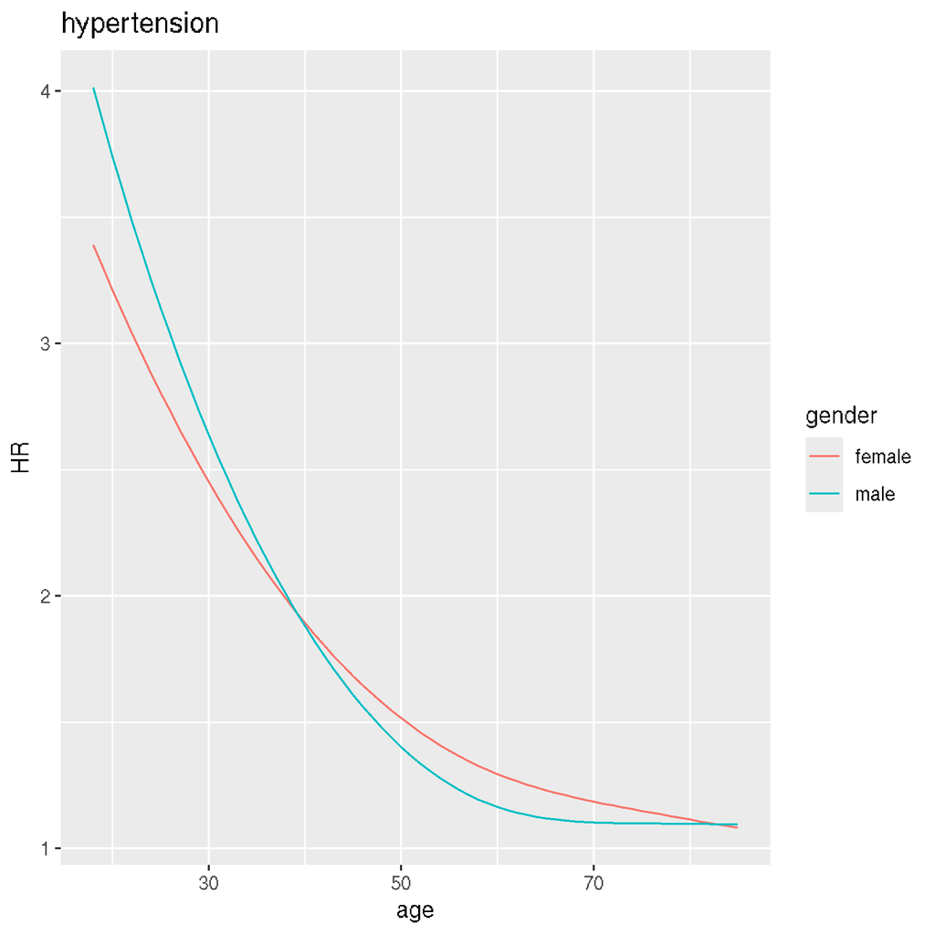

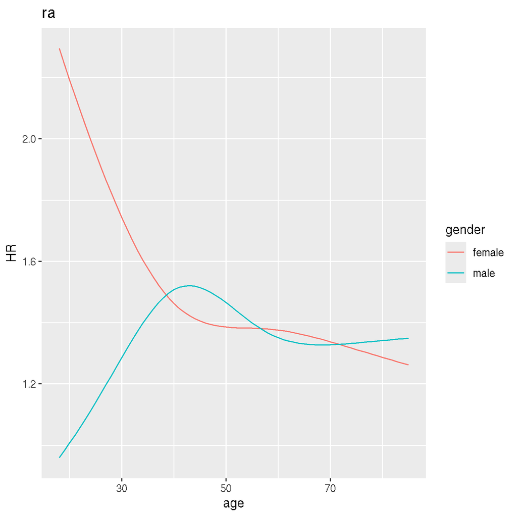

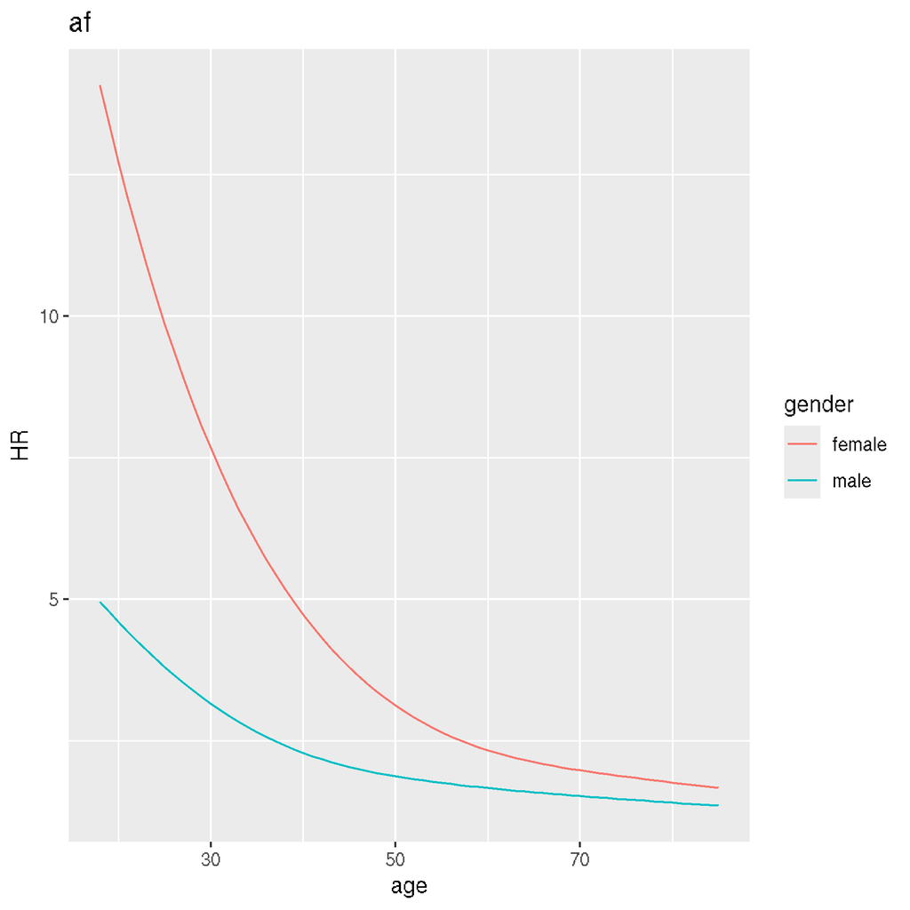

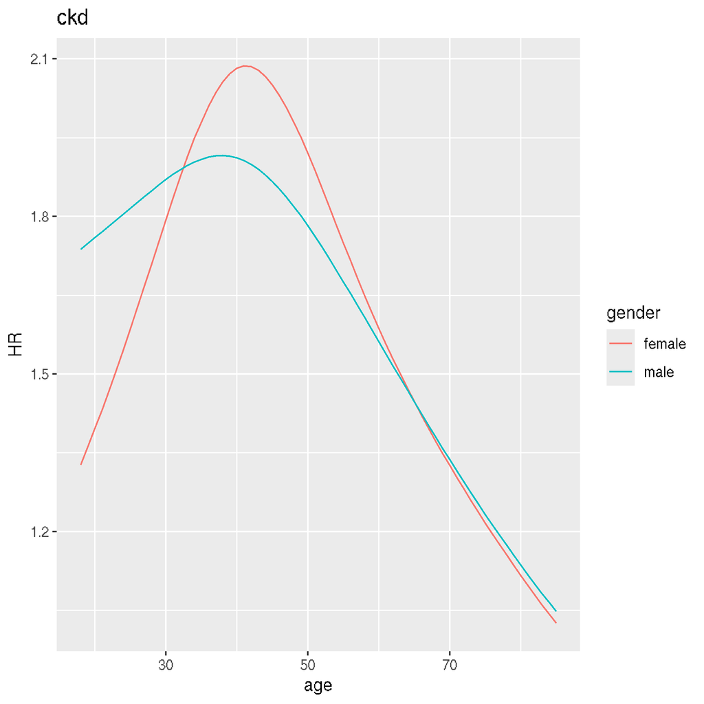

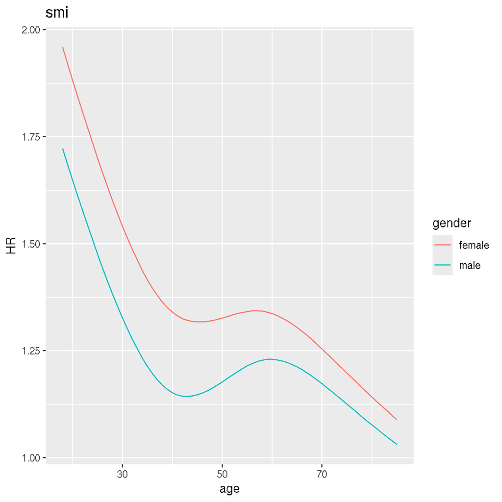

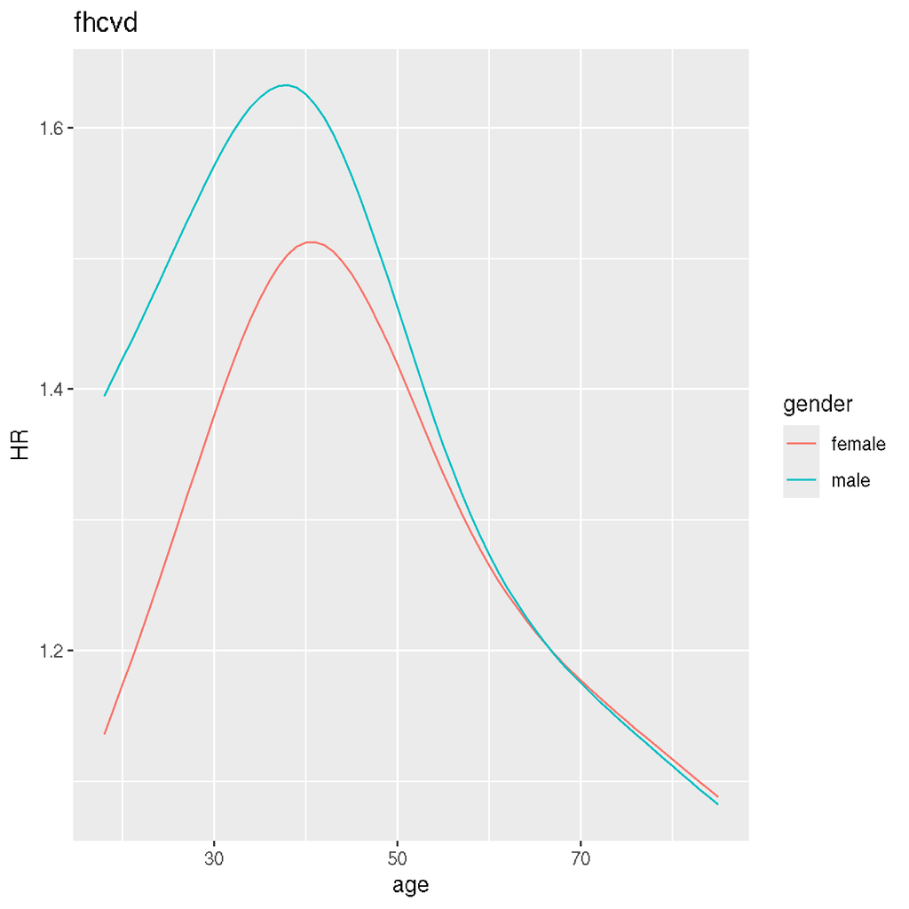

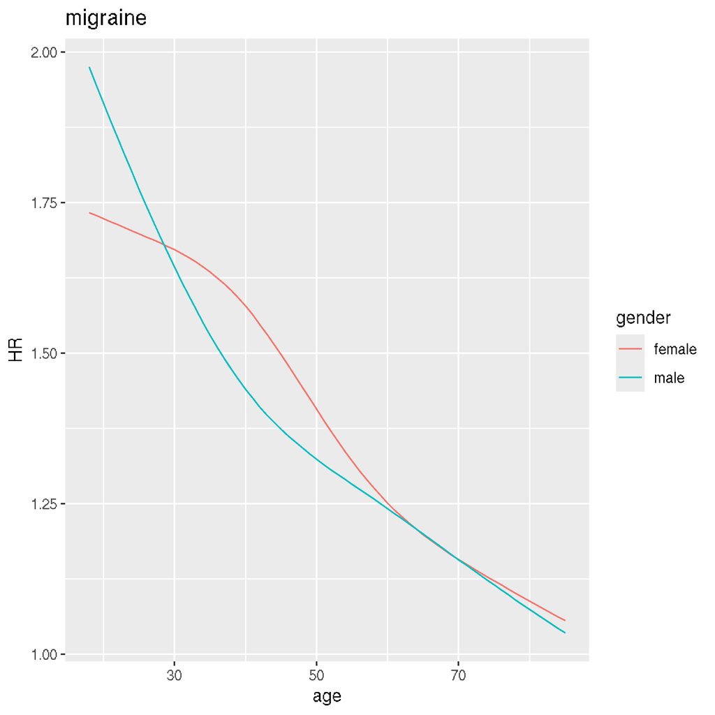

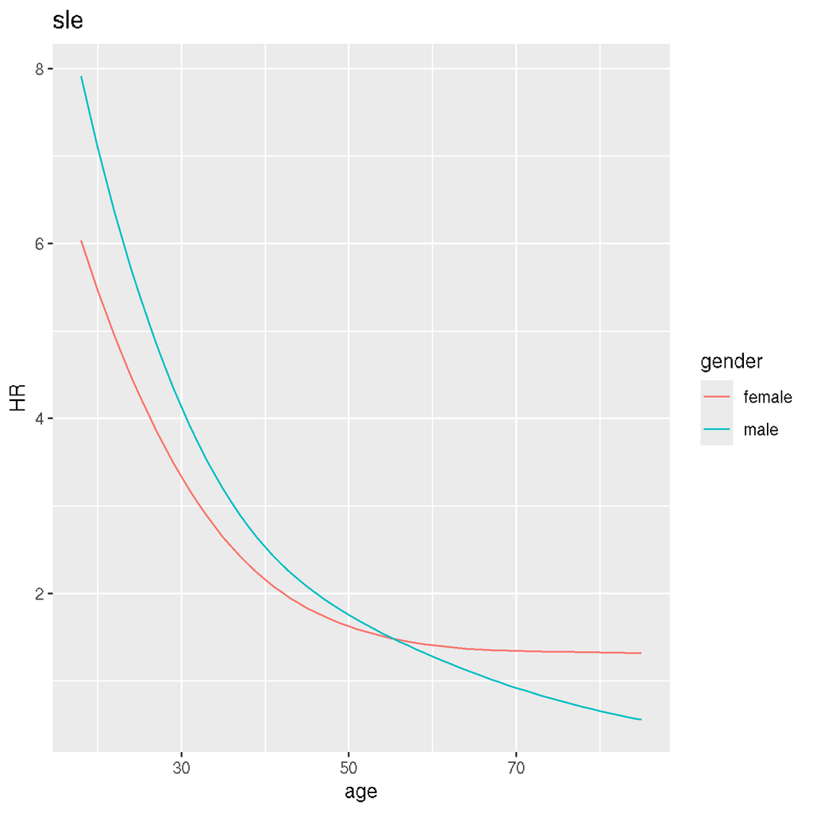

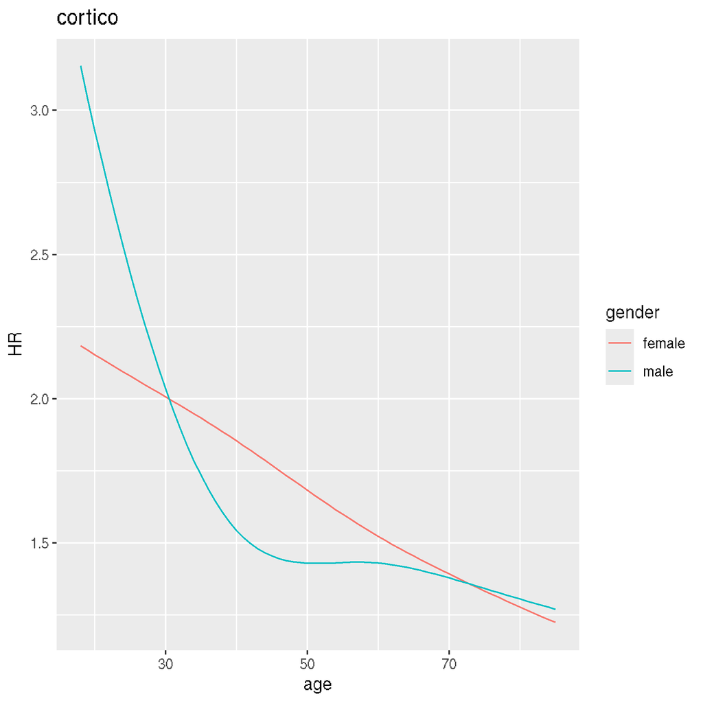

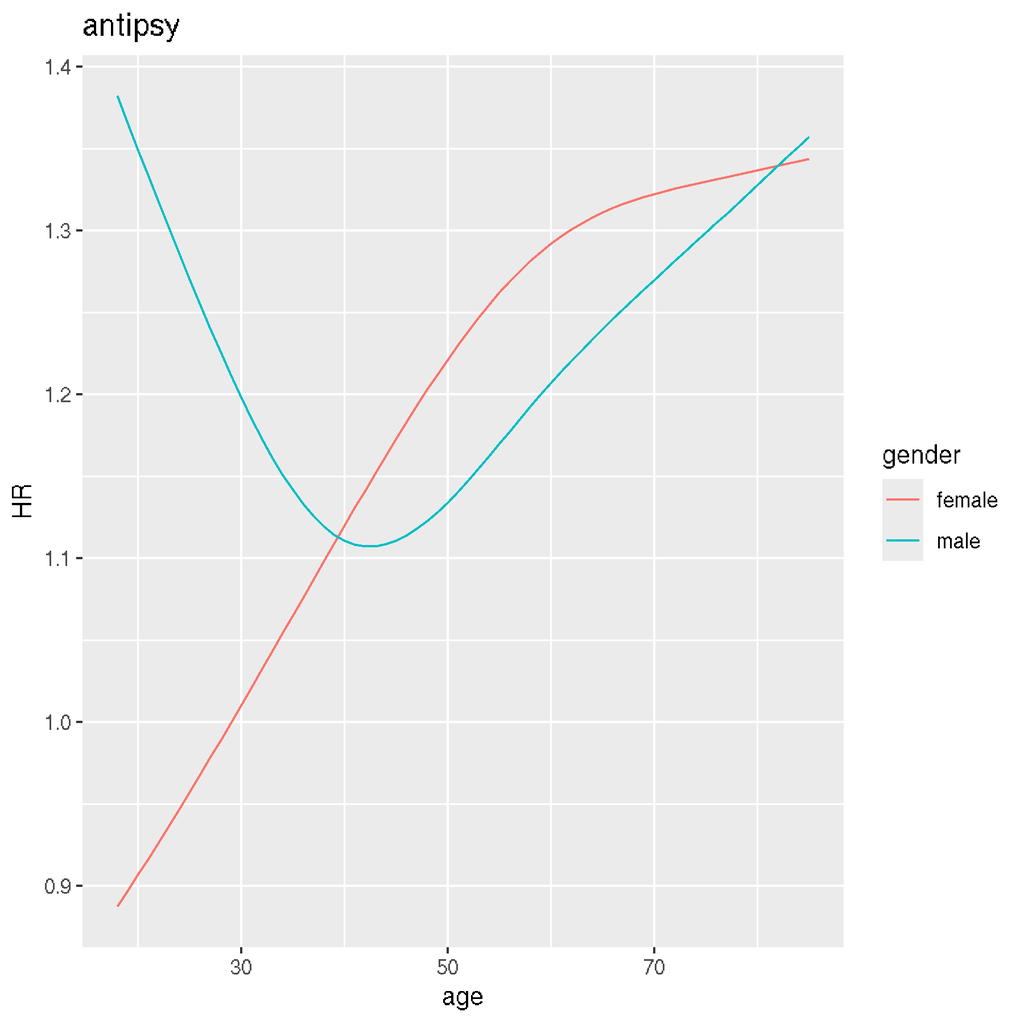

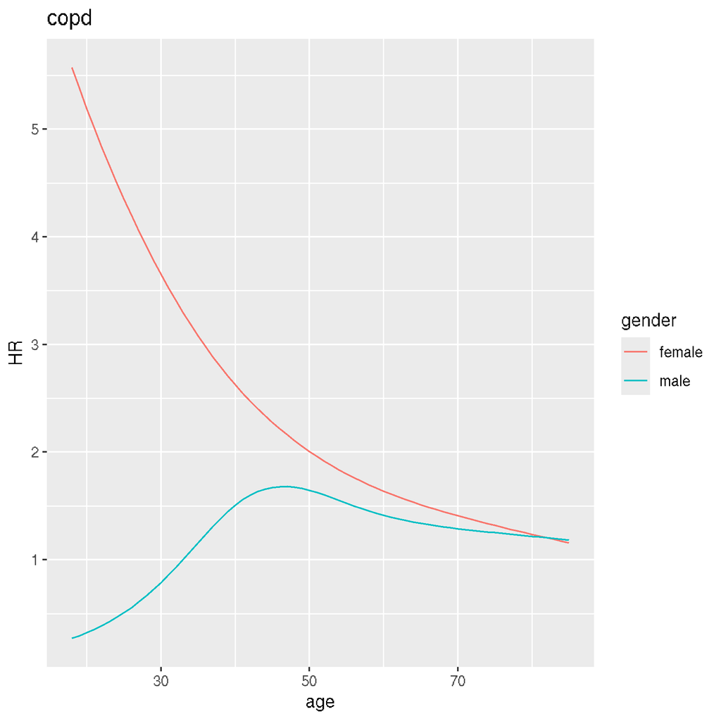

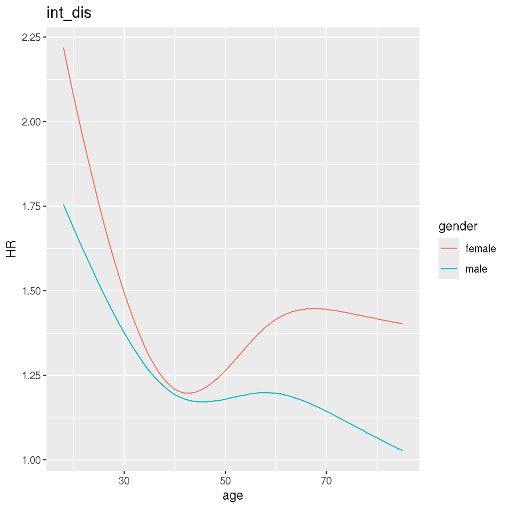

[8 more figures not shown]

## 2.2 Interaction with polytomous predictors

These plots show how the hazard ratio for each polytomous predictor varies over different ages.

**Figure S2. Age interaction with polytomous predictors, female model.**

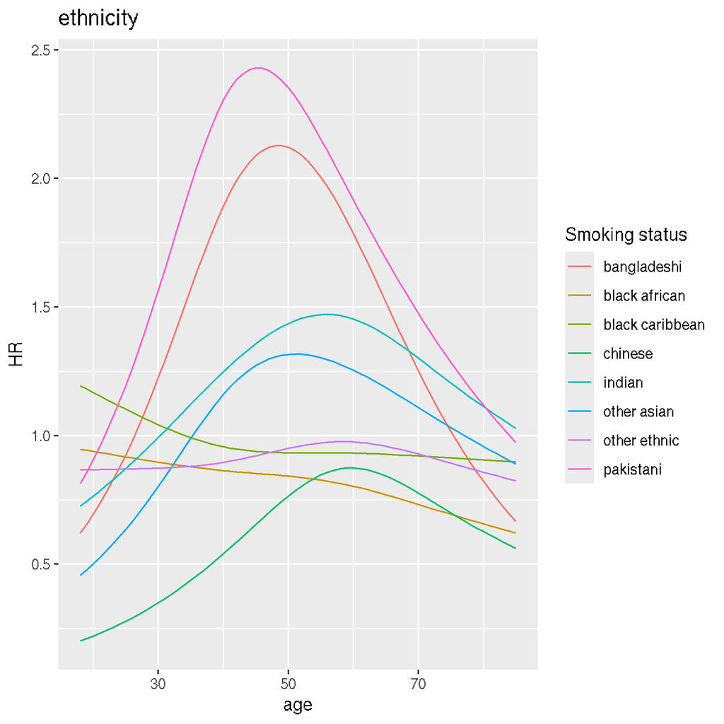

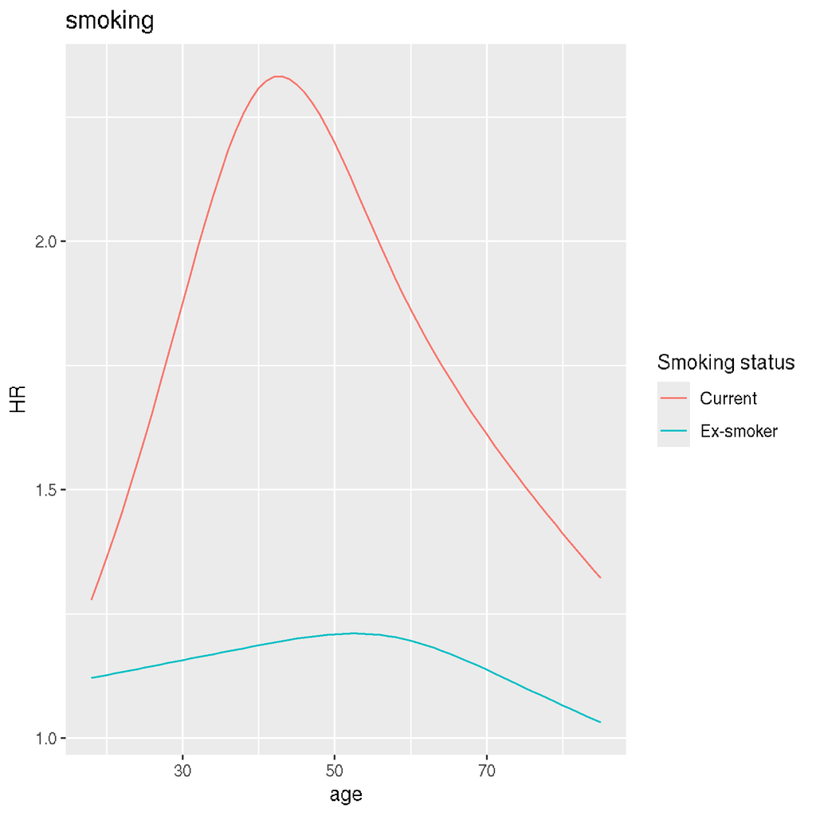

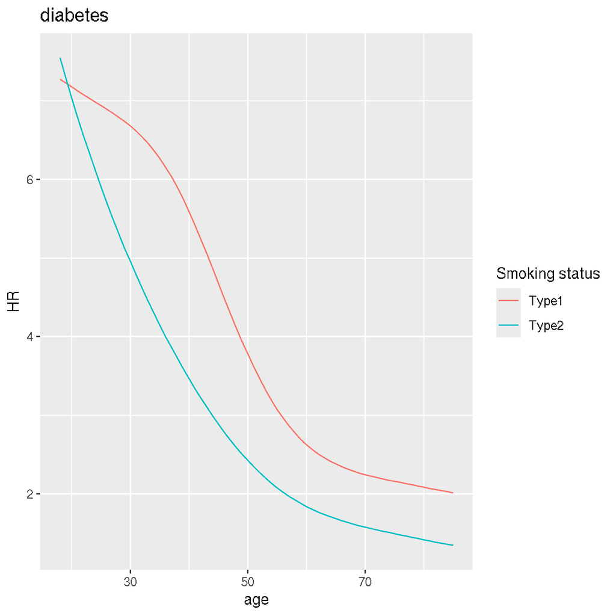

**Figure S3. Age interaction with polytomous predictors, male model.**

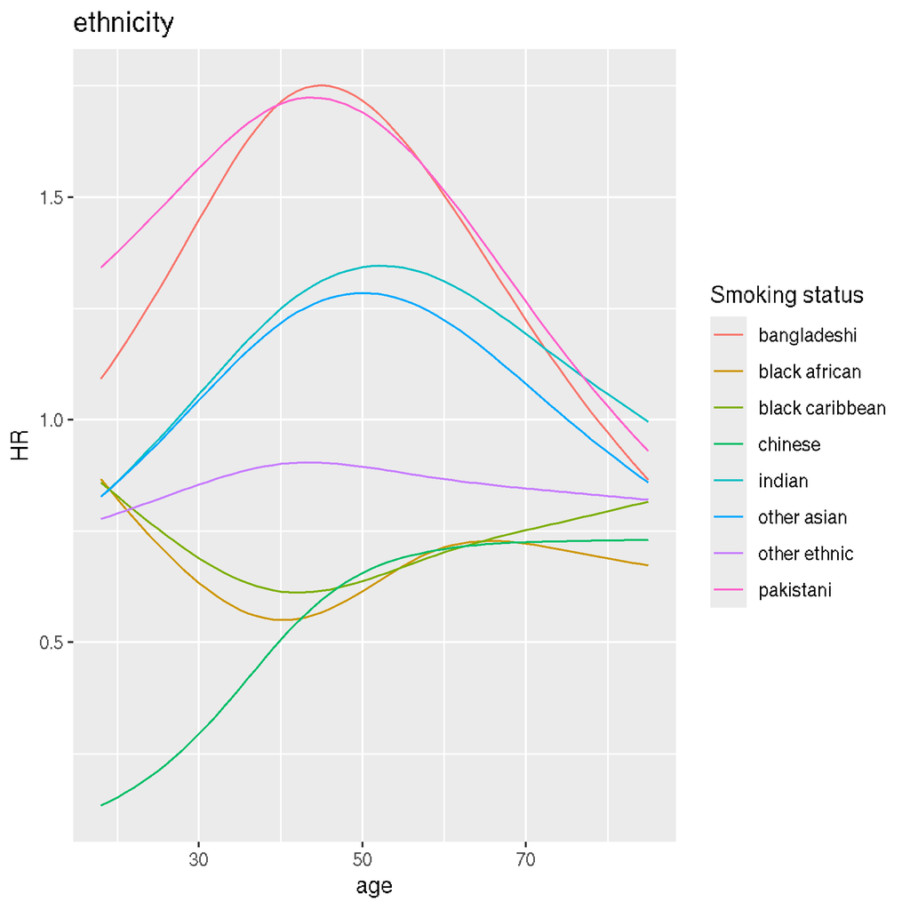

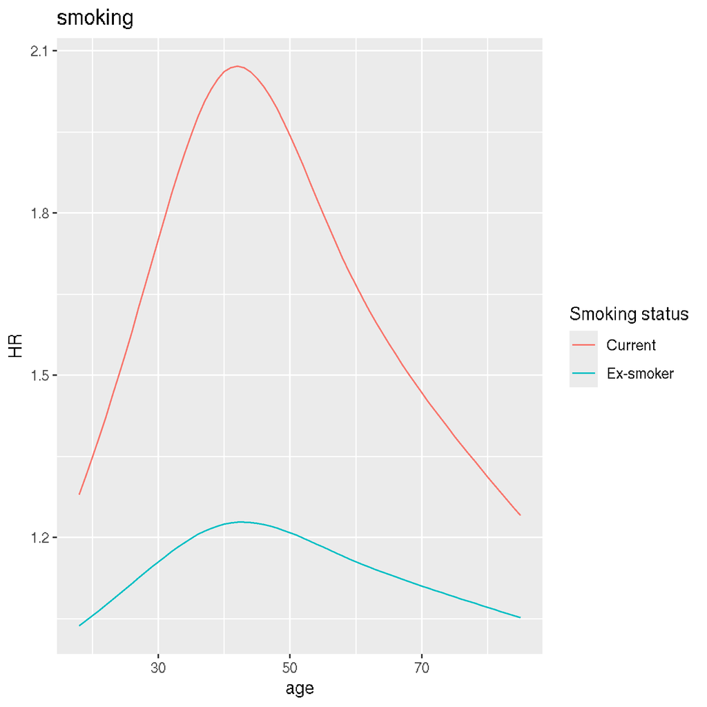

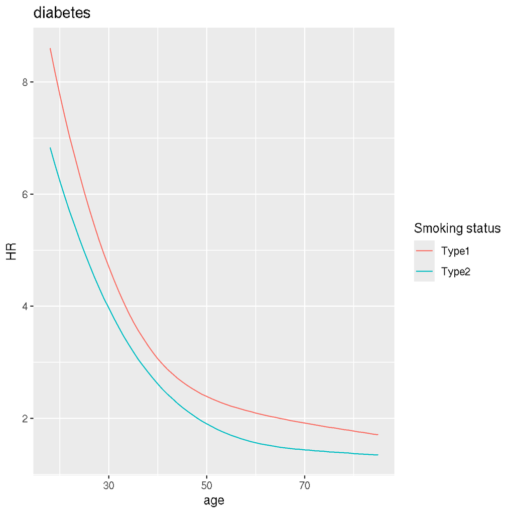

## 2.3 Interaction with continuous predictors

These plots show how the hazard ratio for each continuous predictor varies over its displayed range at different ages.

**Figure S4. Age interaction with continuous predictors, female model.**

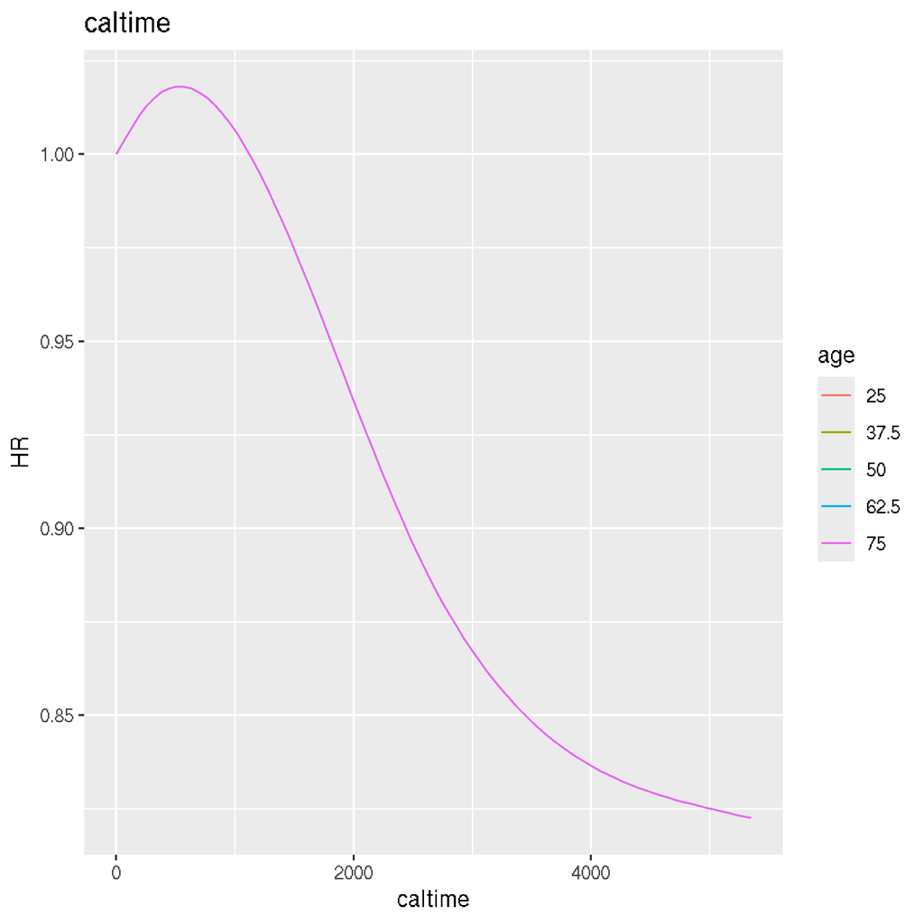

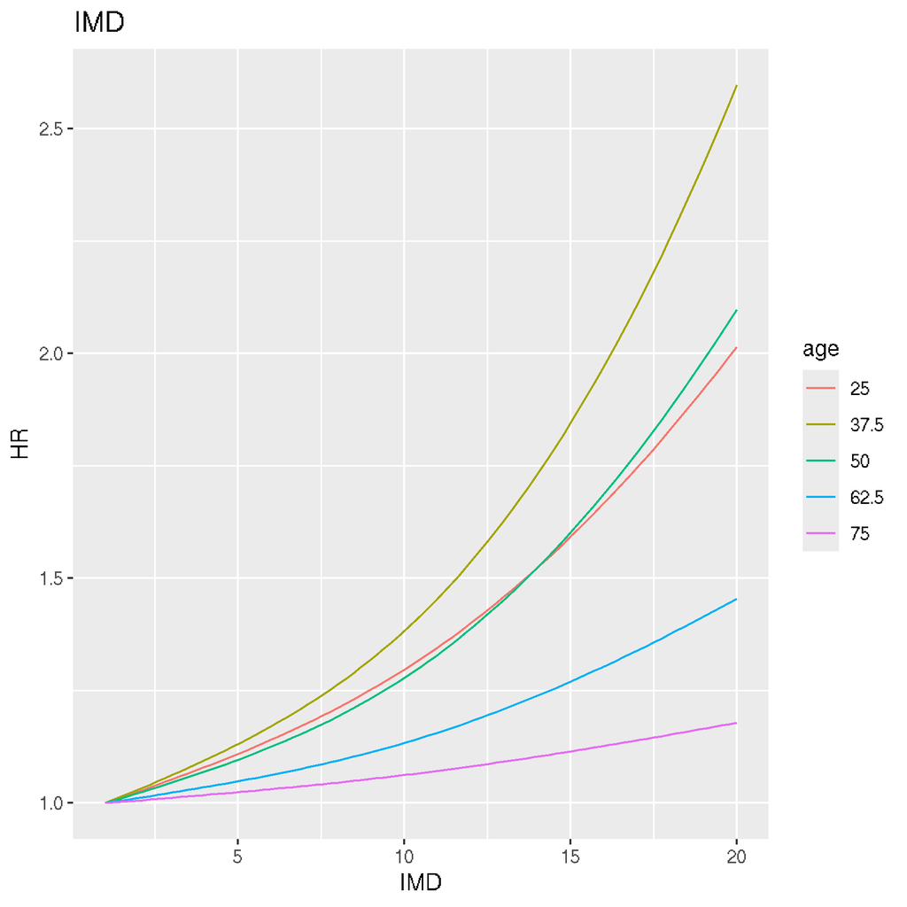

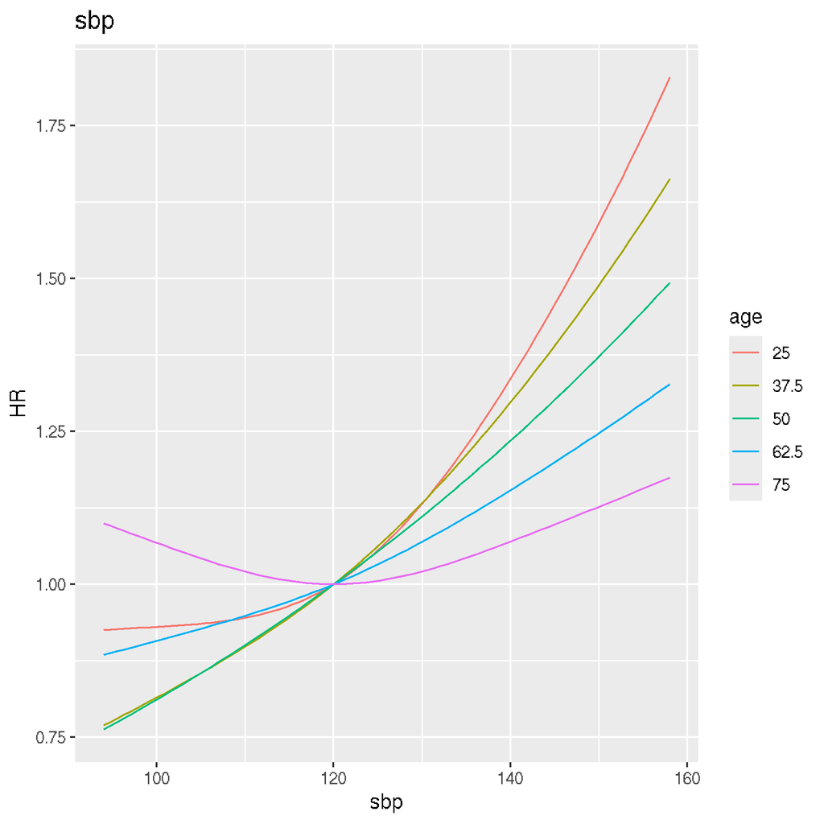

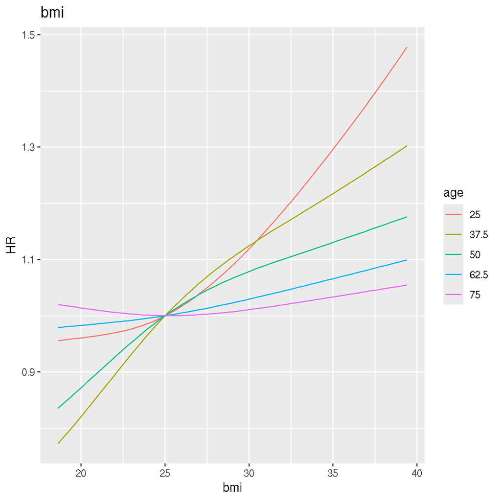

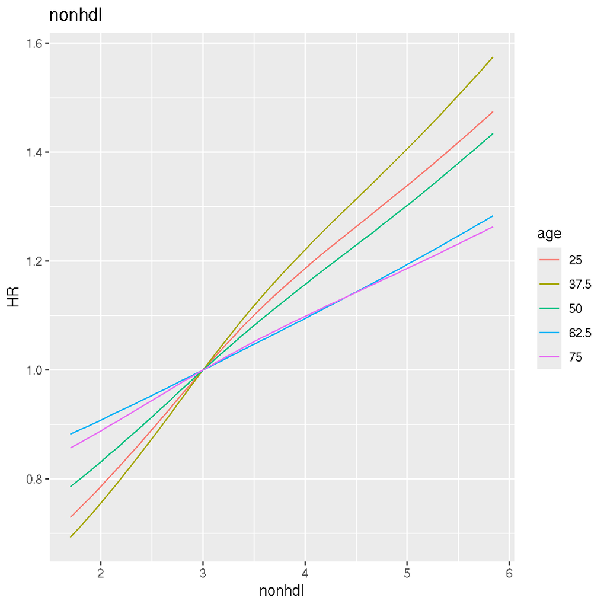

**Figure S5. Age interaction with continuous predictors, male model.**

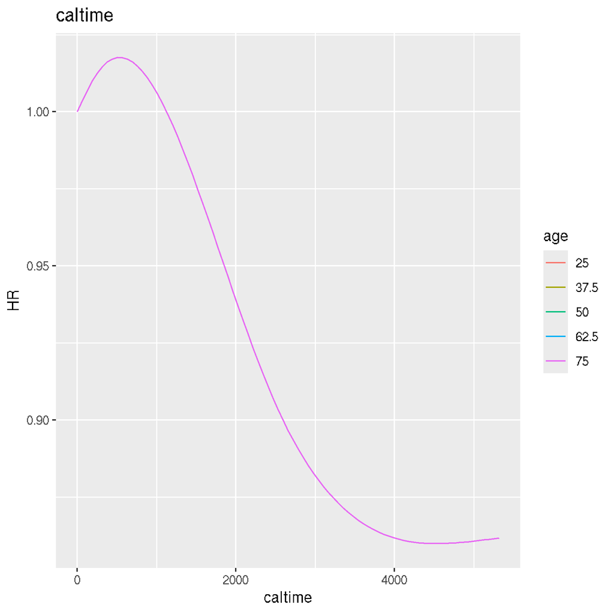

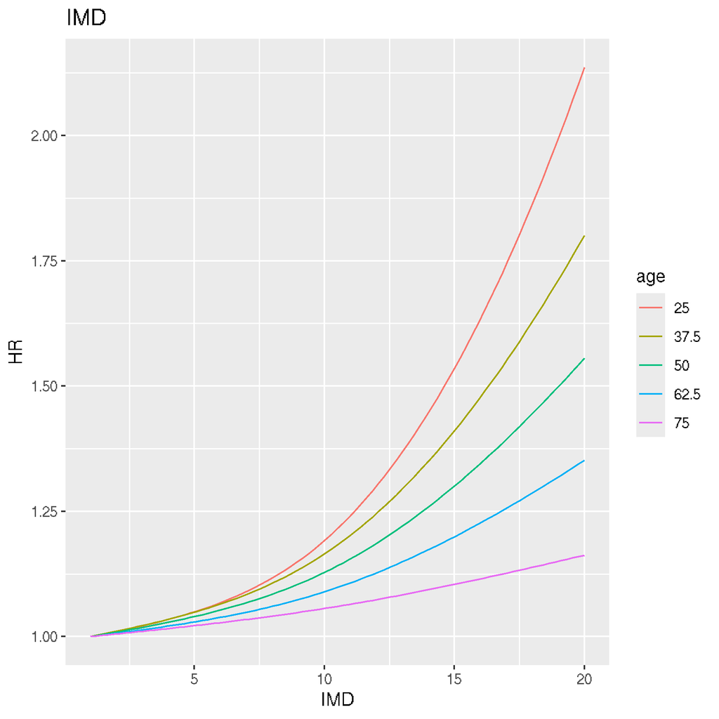

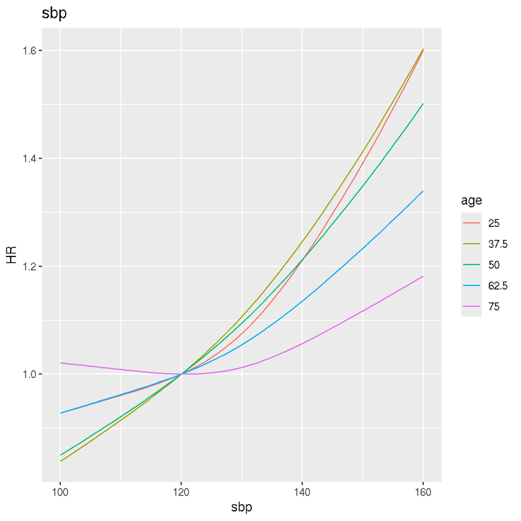

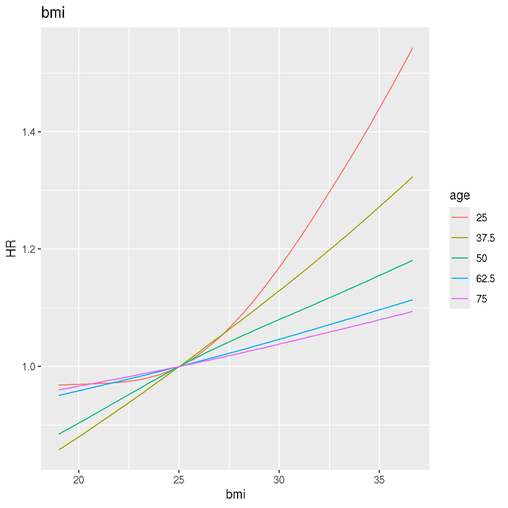

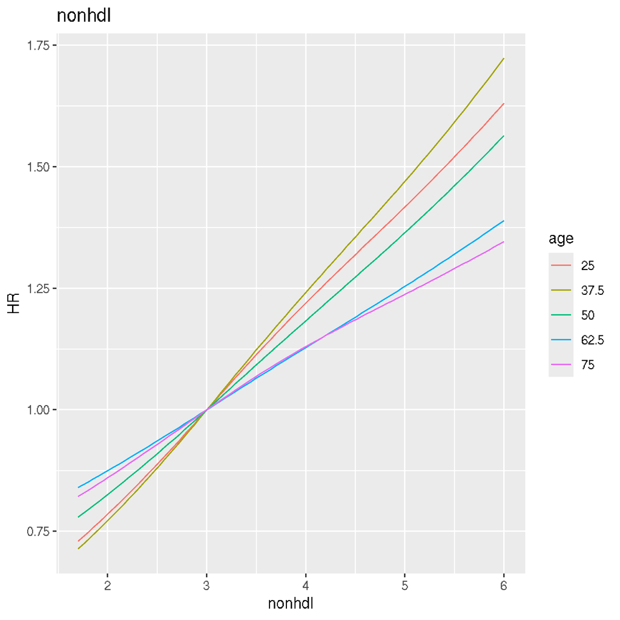

## 2.4 Hazard ratio for age

The hazard ratio for age is evaluated at the reference values of the categorical predictors and the specified values of the continuous predictors, relative to age 40 years.

**Figure S6. Hazard ratio for age.**

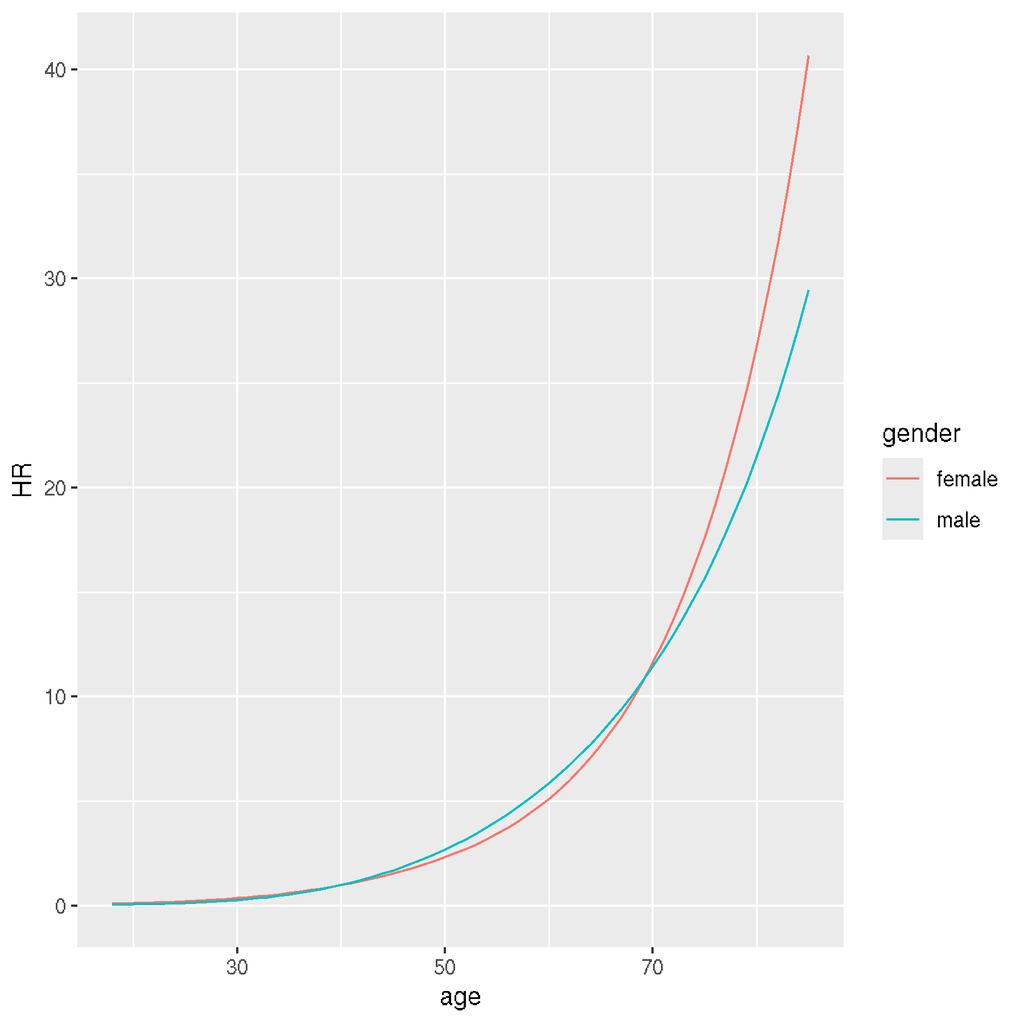

# 3 Internal validation (optimism-adjusted values)

## 3.1 ICI, E50, E90 and discrimination by subgroup

The optimism-adjusted estimate is apparent performance minus mean paired optimism. The **Optimism (p2.5 - p97.5)** column shows percentiles of the optimism distribution, not a confidence interval for the optimism-adjusted estimate. N is displayed as a whole number; for ethnicity, the underlying N is the mean across imputations.

Table S6. Internal validation performance, female model.

| Analysis | Subgroup | N | Metric | Apparent | Optimism-adjusted | Optimism (p2.5 - p97.5) |
| --- | --- | --- | --- | --- | --- | --- |
| Overall | Overall | 9,899,565 | ICI | 0.001 | 0.001 | -0.000 - 0.000 |
| Overall | Overall | 9,899,565 | E50 | 0.000 | 0.000 | -0.000 - 0.000 |
| Overall | Overall | 9,899,565 | E90 | 0.002 | 0.002 | -0.001 - 0.000 |
| Overall | Overall | 9,899,565 | Discrimination | 0.875 | 0.875 | -0.000 - 0.001 |
| Ethnicity | bangladeshi | 69,993 | ICI | 0.002 | 0.002 | -0.001 - 0.001 |
| Ethnicity | bangladeshi | 69,993 | E50 | 0.001 | 0.001 | -0.001 - 0.001 |
| Ethnicity | bangladeshi | 69,993 | E90 | 0.004 | 0.005 | -0.006 - 0.005 |
| Ethnicity | bangladeshi | 69,993 | Discrimination | 0.910 | 0.909 | -0.008 - 0.007 |
| Ethnicity | black african | 296,176 | ICI | 0.000 | 0.000 | -0.001 - 0.000 |
| Ethnicity | black african | 296,176 | E50 | 0.000 | 0.000 | -0.000 - 0.000 |
| Ethnicity | black african | 296,176 | E90 | 0.000 | 0.000 | -0.002 - 0.001 |
| Ethnicity | black african | 296,176 | Discrimination | 0.867 | 0.868 | -0.010 - 0.009 |
| Ethnicity | black caribbean | 139,626 | ICI | 0.001 | 0.001 | -0.001 - 0.001 |
| Ethnicity | black caribbean | 139,626 | E50 | 0.000 | 0.000 | -0.001 - 0.001 |
| Ethnicity | black caribbean | 139,626 | E90 | 0.002 | 0.002 | -0.004 - 0.003 |
| Ethnicity | black caribbean | 139,626 | Discrimination | 0.862 | 0.862 | -0.006 - 0.006 |
| Ethnicity | chinese | 187,315 | ICI | 0.000 | 0.000 | -0.000 - 0.000 |
| Ethnicity | chinese | 187,315 | E50 | 0.000 | 0.000 | -0.000 - 0.000 |
| Ethnicity | chinese | 187,315 | E90 | 0.000 | 0.000 | -0.001 - 0.001 |
| Ethnicity | chinese | 187,315 | Discrimination | 0.928 | 0.927 | -0.014 - 0.014 |
| Ethnicity | indian | 299,858 | ICI | 0.000 | 0.000 | -0.001 - 0.001 |
| Ethnicity | indian | 299,858 | E50 | 0.000 | 0.000 | -0.000 - 0.000 |
| Ethnicity | indian | 299,858 | E90 | 0.002 | 0.001 | -0.002 - 0.003 |
| Ethnicity | indian | 299,858 | Discrimination | 0.896 | 0.896 | -0.004 - 0.004 |
| Ethnicity | other asian | 247,806 | ICI | 0.000 | 0.000 | -0.001 - 0.000 |
| Ethnicity | other asian | 247,806 | E50 | 0.000 | 0.000 | -0.000 - 0.000 |
| Ethnicity | other asian | 247,806 | E90 | 0.001 | 0.001 | -0.002 - 0.001 |
| Ethnicity | other asian | 247,806 | Discrimination | 0.908 | 0.908 | -0.006 - 0.007 |
| Ethnicity | other ethnic | 553,060 | ICI | 0.000 | 0.000 | -0.000 - 0.000 |
| Ethnicity | other ethnic | 553,060 | E50 | 0.000 | 0.000 | -0.000 - 0.000 |

[output cut: 78 more lines]

Table S7. Internal validation performance, male model.

| Analysis | Subgroup | N | Metric | Apparent | Optimism-adjusted | Optimism (p2.5 - p97.5) |
| --- | --- | --- | --- | --- | --- | --- |
| Overall | Overall | 9,510,838 | ICI | 0.001 | 0.001 | -0.000 - 0.000 |
| Overall | Overall | 9,510,838 | E50 | 0.001 | 0.001 | -0.000 - 0.000 |
| Overall | Overall | 9,510,838 | E90 | 0.002 | 0.002 | -0.001 - 0.001 |
| Overall | Overall | 9,510,838 | Discrimination | 0.859 | 0.859 | -0.000 - 0.001 |
| Ethnicity | bangladeshi | 86,276 | ICI | 0.001 | 0.001 | -0.001 - 0.001 |
| Ethnicity | bangladeshi | 86,276 | E50 | 0.001 | 0.001 | -0.001 - 0.001 |
| Ethnicity | bangladeshi | 86,276 | E90 | 0.002 | 0.002 | -0.005 - 0.003 |
| Ethnicity | bangladeshi | 86,276 | Discrimination | 0.898 | 0.898 | -0.006 - 0.006 |
| Ethnicity | black african | 291,405 | ICI | 0.001 | 0.001 | -0.001 - 0.001 |
| Ethnicity | black african | 291,405 | E50 | 0.000 | 0.000 | -0.000 - 0.001 |
| Ethnicity | black african | 291,405 | E90 | 0.001 | 0.001 | -0.002 - 0.002 |
| Ethnicity | black african | 291,405 | Discrimination | 0.880 | 0.879 | -0.006 - 0.007 |
| Ethnicity | black caribbean | 125,973 | ICI | 0.001 | 0.001 | -0.001 - 0.001 |
| Ethnicity | black caribbean | 125,973 | E50 | 0.000 | 0.000 | -0.001 - 0.001 |
| Ethnicity | black caribbean | 125,973 | E90 | 0.003 | 0.003 | -0.005 - 0.004 |
| Ethnicity | black caribbean | 125,973 | Discrimination | 0.876 | 0.877 | -0.005 - 0.004 |
| Ethnicity | chinese | 139,811 | ICI | 0.000 | 0.000 | -0.001 - 0.000 |
| Ethnicity | chinese | 139,811 | E50 | 0.000 | 0.000 | -0.000 - 0.000 |
| Ethnicity | chinese | 139,811 | E90 | 0.000 | 0.001 | -0.002 - 0.001 |
| Ethnicity | chinese | 139,811 | Discrimination | 0.933 | 0.932 | -0.008 - 0.008 |
| Ethnicity | indian | 339,686 | ICI | 0.001 | 0.001 | -0.001 - 0.001 |
| Ethnicity | indian | 339,686 | E50 | 0.000 | 0.000 | -0.001 - 0.001 |
| Ethnicity | indian | 339,686 | E90 | 0.003 | 0.003 | -0.004 - 0.003 |
| Ethnicity | indian | 339,686 | Discrimination | 0.889 | 0.889 | -0.003 - 0.003 |
| Ethnicity | other asian | 270,214 | ICI | 0.000 | 0.000 | -0.001 - 0.001 |
| Ethnicity | other asian | 270,214 | E50 | 0.000 | 0.000 | -0.001 - 0.001 |
| Ethnicity | other asian | 270,214 | E90 | 0.000 | 0.001 | -0.003 - 0.002 |
| Ethnicity | other asian | 270,214 | Discrimination | 0.888 | 0.889 | -0.005 - 0.004 |
| Ethnicity | other ethnic | 540,778 | ICI | 0.000 | 0.000 | -0.000 - 0.000 |
| Ethnicity | other ethnic | 540,778 | E50 | 0.000 | 0.000 | -0.000 - 0.000 |

[output cut: 78 more lines]

## 3.2 Calibration plots

### 3.2.1 Entire cohort: median curves and median observed versus expected

**Figure S7. Internal-validation calibration, entire cohort (female and male models).**

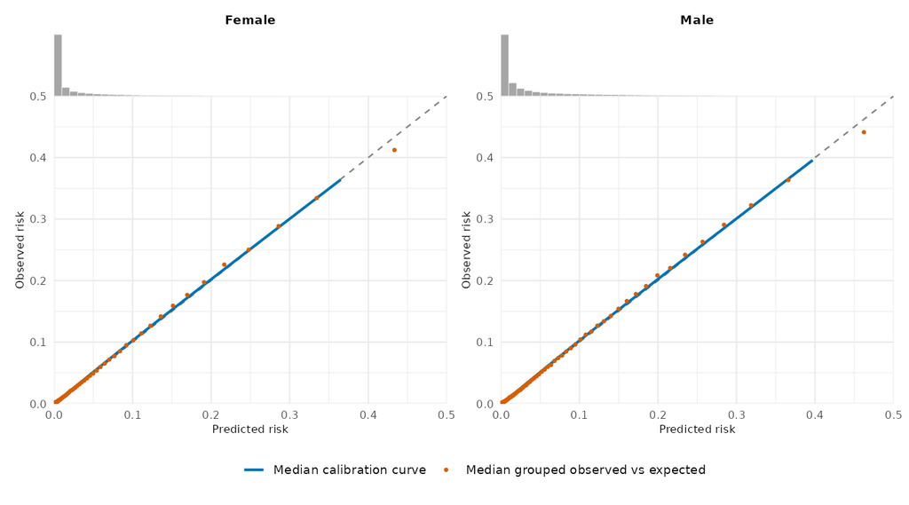